# AN597_Zombies_mjsalnic

majo

7/10/2019

##Challenges

- 1. problem 1: Question 5, I am not sure which code to use for confidence intervals when it a right skewed distribution
  2. problem 2: Question 6, I could do the 99 more random samples of 30 zombie apocalypse survivors but then I could not extract each varibale from each replication and find the mean of means for each variable

##1. Calculate the population mean and standard deviation for each quantitative random variable (height, weight, age, number of zombies killed, and years of education). NOTE: You will not want to use the built in var() and sd() commands as these are for samples.

```r
library(curl)
f <- f <- curl("https://raw.githubusercontent.com/fuzzyatelin/fuzzyatelin.github.io/master/AN597_Fall19/zombies.csv")
d <- read.csv(f, header = TRUE, sep = ",", stringsAsFactors = FALSE)
summary(d)
```

```
##        id          first_name         last_name            gender
##  Min.   :   1.0   Length:1000        Length:1000        Length:1000
##  1st Qu.: 250.8   Class :character   Class :character   Class :character
##  Median : 500.5   Mode  :character   Mode  :character   Mode  :character
##  Mean   : 500.5
##  3rd Qu.: 750.2
##  Max.   :1000.0
##      height          weight       zombies_killed   years_of_education
##  Min.   :54.15   Min.   : 90.29   Min.   : 0.000   Min.   :0.000
##  1st Qu.:64.68   1st Qu.:131.81   1st Qu.: 2.000   1st Qu.:2.000
##  Median :67.50   Median :142.89   Median : 3.000   Median :3.000
##  Mean   :67.63   Mean   :143.91   Mean   : 2.992   Mean   :2.996
##  3rd Qu.:70.38   3rd Qu.:156.28   3rd Qu.: 4.000   3rd Qu.:4.000
##  Max.   :80.53   Max.   :210.79   Max.   :11.000   Max.   :8.000
##     major                age
##  Length:1000        Min.   :10.66
##  Class :character   1st Qu.:18.07
##  Mode  :character   Median :19.90
##                     Mean   :20.05
##                     3rd Qu.:21.94
##                     Max.   :29.59
```

```r
attach(d)
mean(height)
```

```
## [1] 67.6301
```

```r
Height_sigma<- sqrt(sum((height - mean(height))^2)/length(height))
Height_sigma
```

```
## [1] 4.30797
```

```r
mean(weight)
```

```
## [1] 143.9075
```

```r
weight_sigma<- sqrt(sum((weight - mean(weight))^2)/length(weight))
weight_sigma
```

```
## [1] 18.39186
```

```r
mean(age)
```

```
## [1] 20.04696
```

```r
age_sigma<- sqrt(sum((age - mean(age))^2)/length(age))
age_sigma
```

```
## [1] 2.963583
```

```r
mean(zombies_killed)
```

```
## [1] 2.992
```

```r
zombiesKilled_sigma<- sqrt(sum((zombies_killed - mean(zombies_killed))^2)/length(zombies_killed))
zombiesKilled_sigma
```

```
## [1] 1.747551
```

```r
mean(years_of_education)
```

```
## [1] 2.996
```

```r
yearsofedu_sigma<- sqrt(sum((years_of_education - mean(years_of_education))^2)/length(years_of_education))
yearsofedu_sigma
```

```
## [1] 1.675704
```

##2. Use {ggplot} to make boxplots of each of these variables by gender.

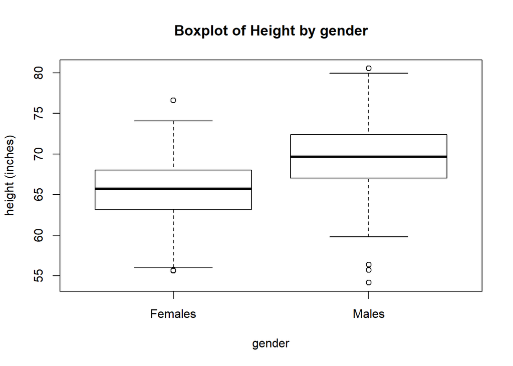

```r
library(ggplot2)
#height by gender
boxplot(height~gender,main="Boxplot of Height by gender", ylab = "height (inches)", names=c("Females", "Males"))
```

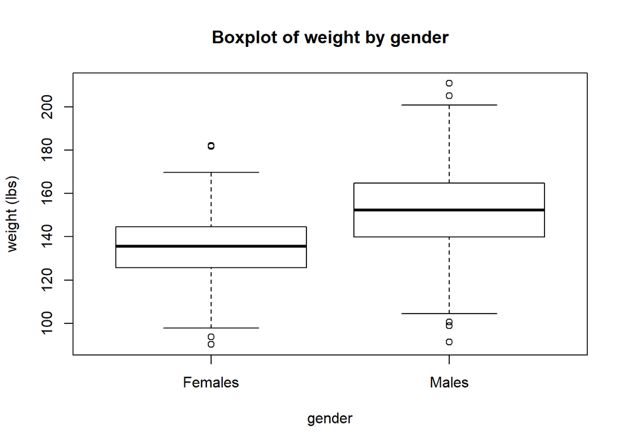

```r
#weight by gender
boxplot(weight~gender,main="Boxplot of weight by gender", ylab = "weight (lbs)", names=c("Females", "Males"))
```

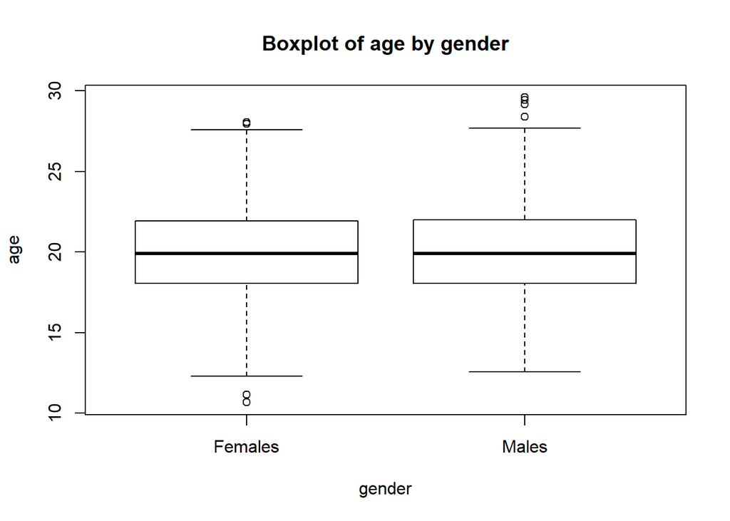

```r
#age by gender
boxplot(age~gender,main="Boxplot of age by gender", ylab = "age", names=c("Females", "Males"))
```

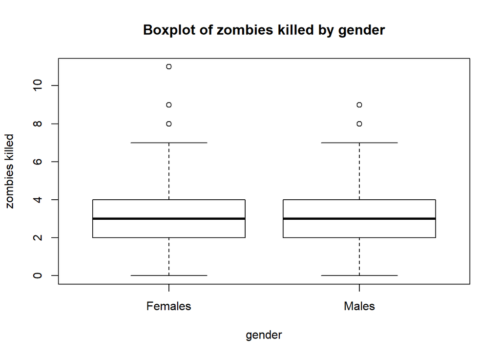

```r
#number of zombies killed  by gender
boxplot(zombies_killed~gender,main="Boxplot of zombies killed by gender", ylab = "zombies killed", names=c("Females", "Males"))
```

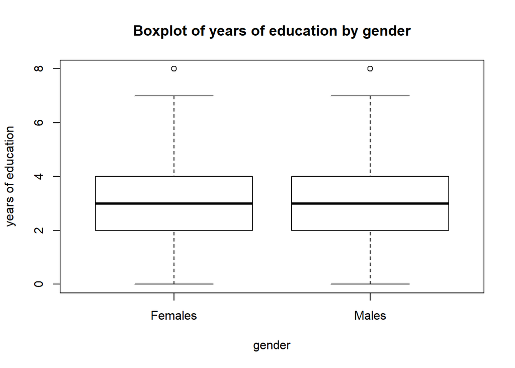

```r
#number of years of education  by gender
boxplot(years_of_education~gender,main="Boxplot of years of education by gender", ylab = "years of education", names=c("Females", "Males"))
```

##3. Use {ggplot} to make scatterplots of height and weight in relation to age. Do these variables seem to be related? In what way?

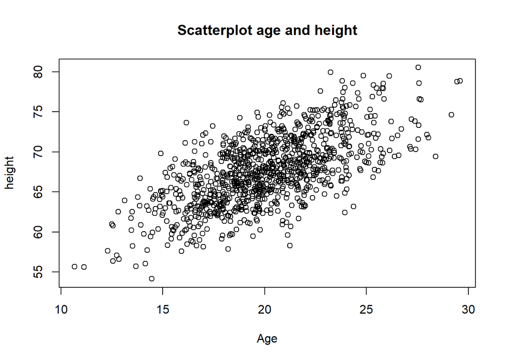

```r
plot(age, height, main = "Scatterplot age and height", xlab = "Age", ylab = "height")
```

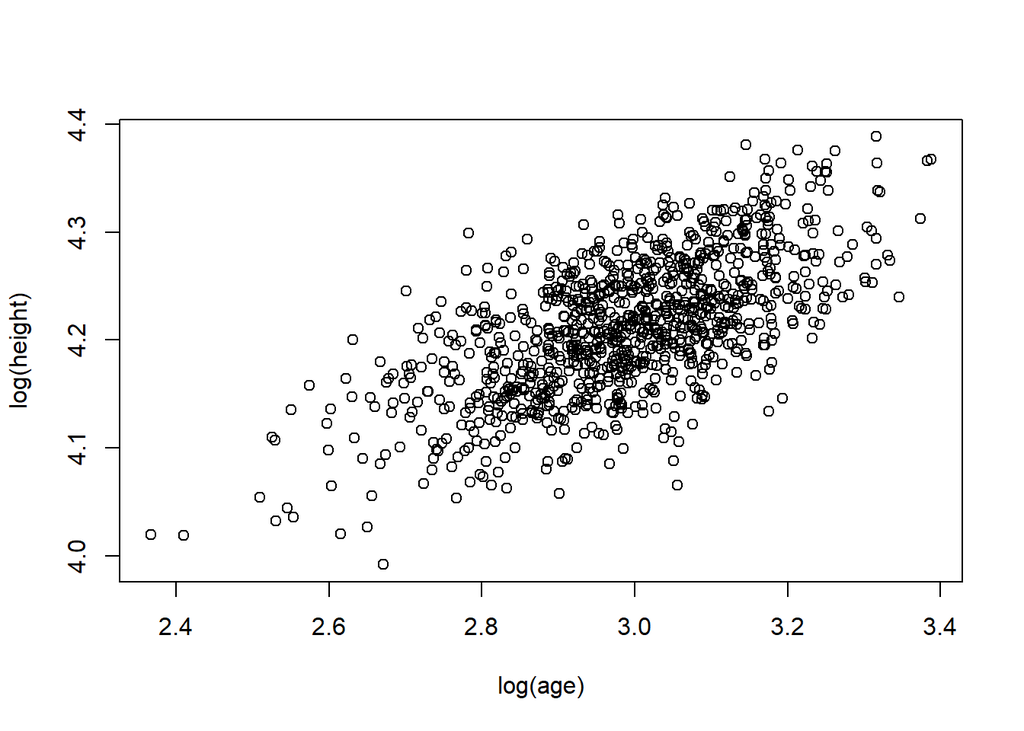

```r
plot(x= log(age), y= log(height))
```

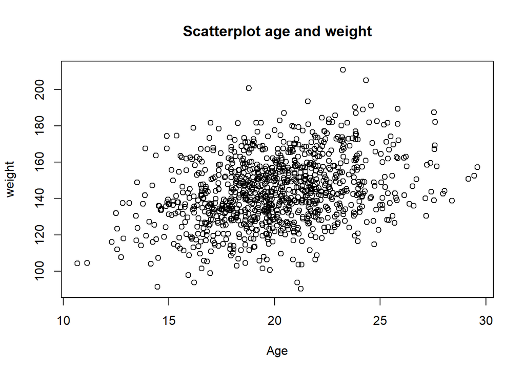

```r
plot(age, weight, main = "Scatterplot age and weight", xlab = "Age", ylab = "weight")
```

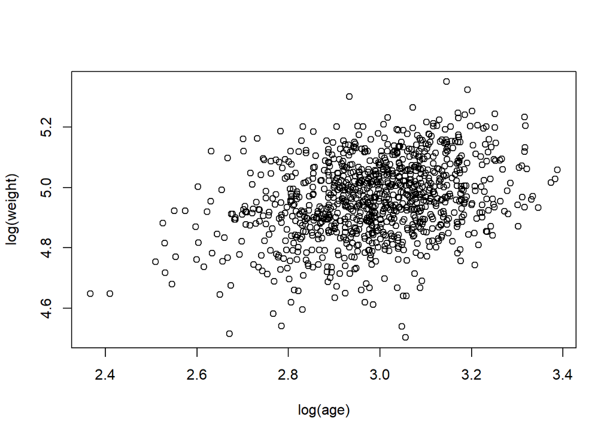

```r
plot(x= log(age), y= log(weight))
```

##4. Using histograms and Q-Q plots, check whether the quantitative variables seem to be drawn from a normal distribution. Which seem to be and which do not (hint: not all are drawn from the normal distribution)? For those that are not normal, can you determine from which common distribution they are drawn?

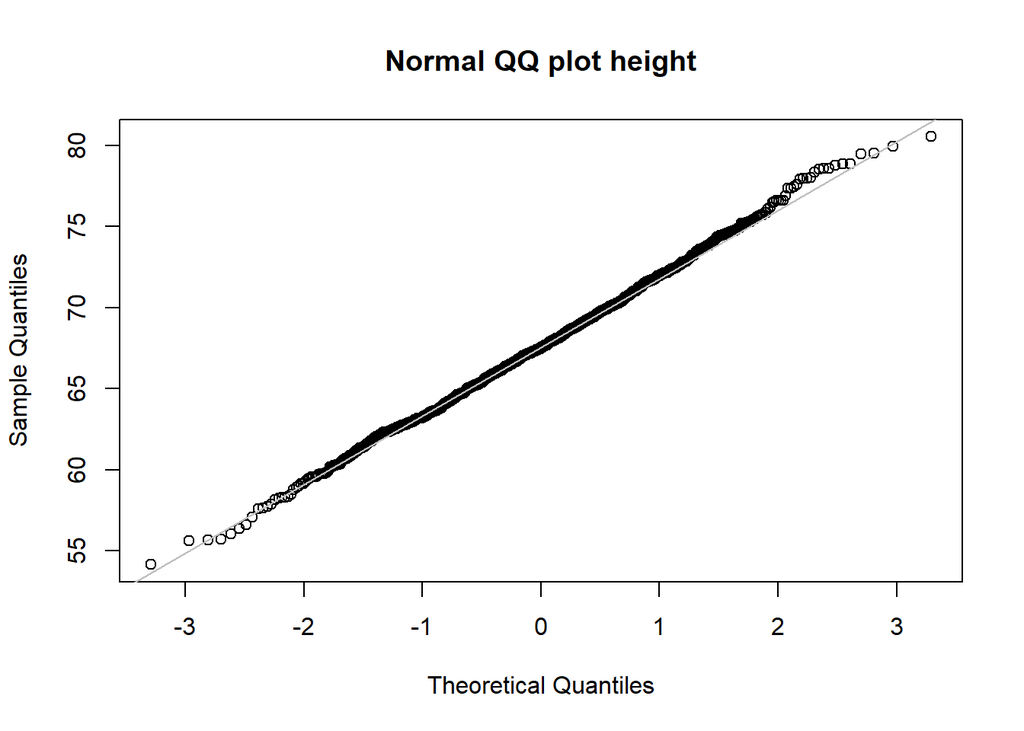

```r
qqnorm(height,main="Normal QQ plot height")
qqline(height,col="gray")
```

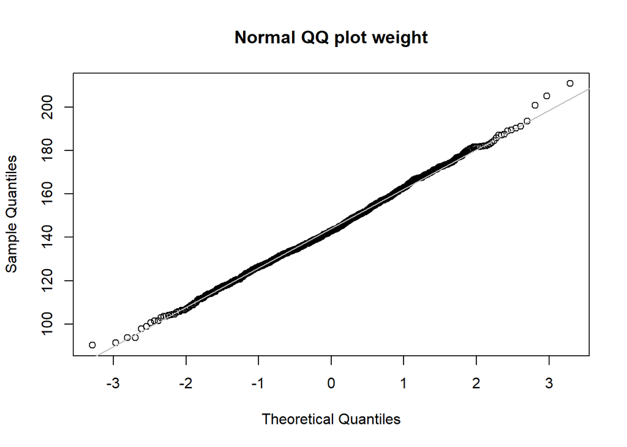

```r
qqnorm(weight,main="Normal QQ plot weight")
qqline(weight,col="gray")
```

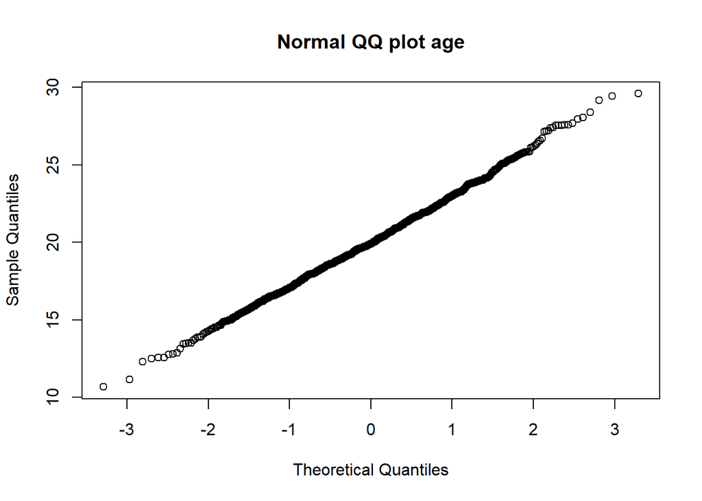

```r
qqnorm(age,main="Normal QQ plot age")
qqline(weight,col="gray")
```

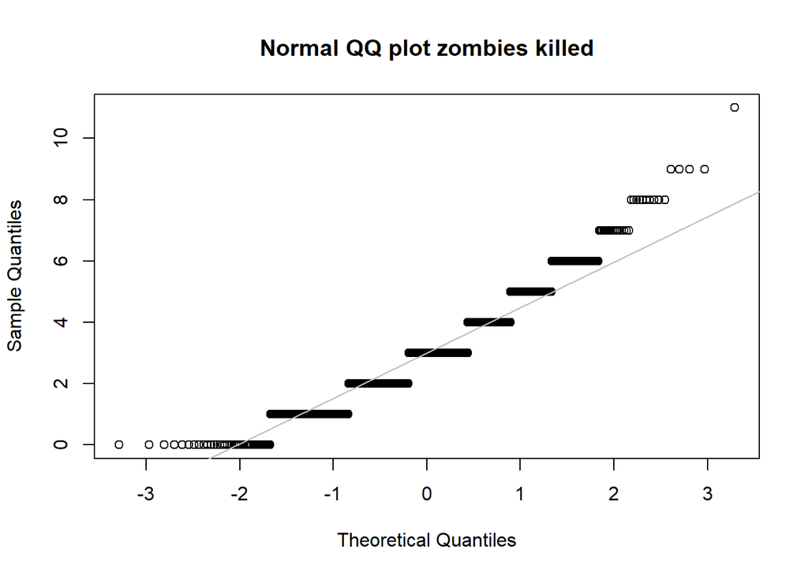

```r
qqnorm(zombies_killed,main="Normal QQ plot zombies killed")
qqline(zombies_killed,col="gray")
```

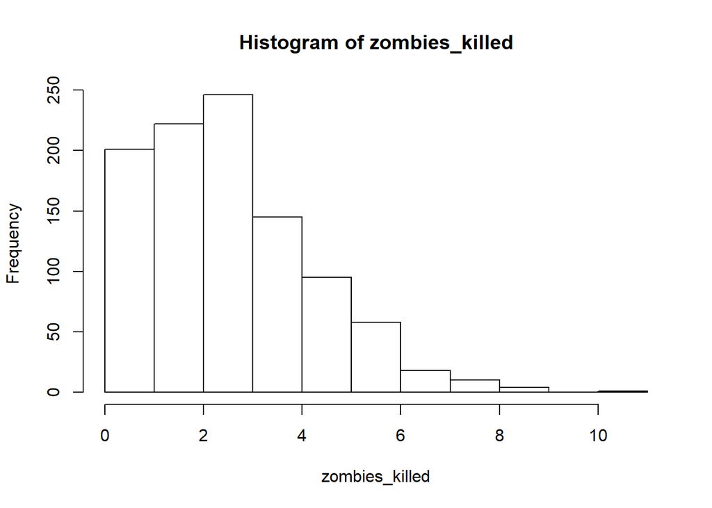

```r
hist(zombies_killed)
```

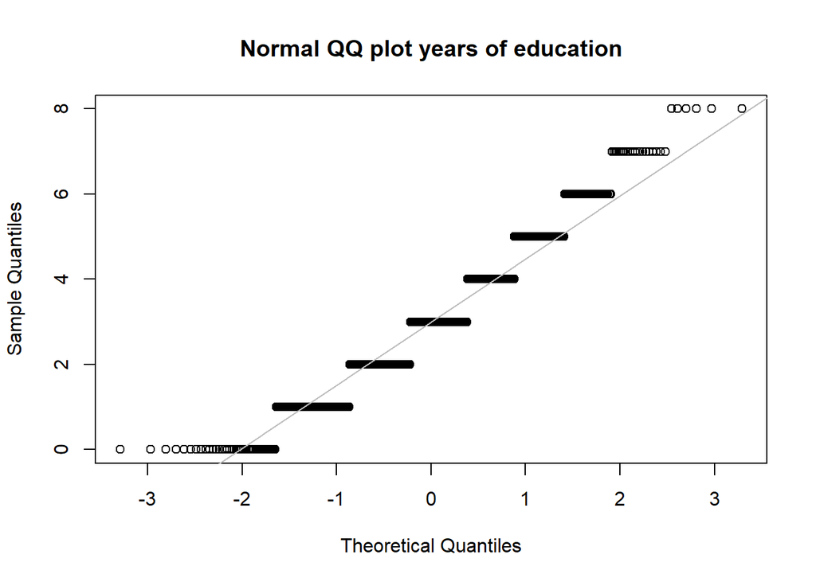

```r
#zombies killed does not drawn from a normal distribution



qqnorm(years_of_education,main="Normal QQ plot years of education")
qqline(years_of_education,col="gray")
```

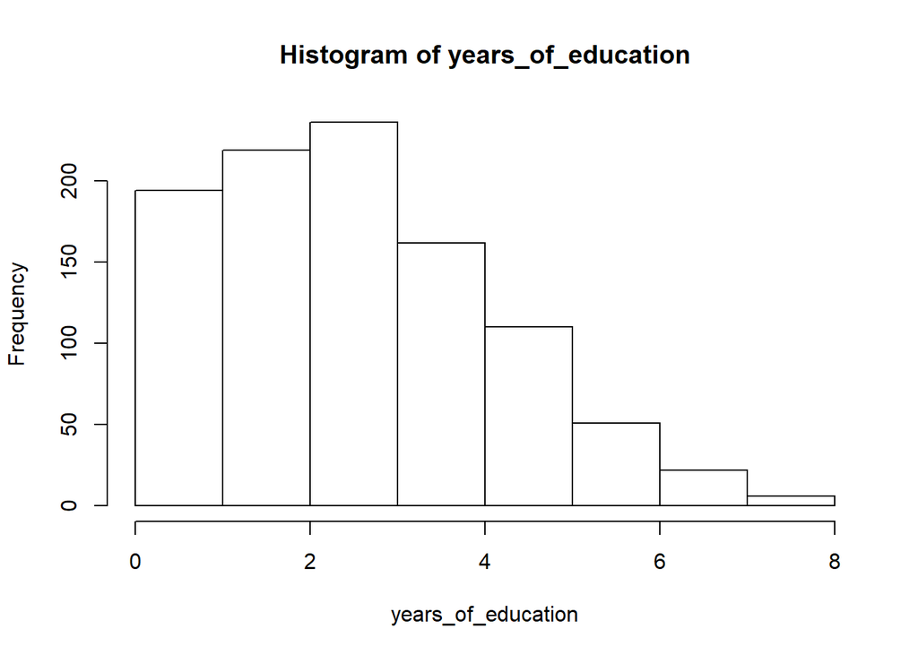

```r
hist(years_of_education)
```

```r
#years of education does not drawn from a normal distribution
```

##5. Now use the sample() function to sample ONE subset of 30 zombie survivors (without replacement) from this population and calculate the mean and sample standard deviation for each variable. Also estimate the standard error for each variable, and construct the 95% confidence interval for each mean. Note that for the variables that are not drawn from the normal distribution, you may need to base your estimate of the CIs on slightly different code than for the normal…

```r
library(sciplot)
sample30<-d[sample(1:nrow(d), 30,
   replace=FALSE),]

detach(d)

attach(sample30)
summary(sample30)
```

```
##        id         first_name         last_name            gender
##  Min.   : 56.0   Length:30          Length:30          Length:30
##  1st Qu.:204.2   Class :character   Class :character   Class :character
##  Median :542.0   Mode  :character   Mode  :character   Mode  :character
##  Mean   :472.8
##  3rd Qu.:651.8
##  Max.   :932.0
##      height          weight      zombies_killed years_of_education
##  Min.   :59.81   Min.   : 99.0   Min.   :0.0    Min.   :1.000
##  1st Qu.:67.21   1st Qu.:138.7   1st Qu.:2.0    1st Qu.:2.000
##  Median :69.08   Median :150.7   Median :2.0    Median :2.500
##  Mean   :68.73   Mean   :147.9   Mean   :2.6    Mean   :3.033
##  3rd Qu.:70.25   3rd Qu.:157.8   3rd Qu.:3.0    3rd Qu.:4.000
##  Max.   :79.52   Max.   :182.6   Max.   :7.0    Max.   :7.000
##     major                age
##  Length:30          Min.   :14.50
##  Class :character   1st Qu.:17.77
##  Mode  :character   Median :19.45
##                     Mean   :19.64
##                     3rd Qu.:21.15
##                     Max.   :27.68
```

```r
##Height
mean(sample30$height)
```

```
## [1] 68.73429
```

```r
sd(sample30$height)
```

```
## [1] 4.060593
```

```r
se(sample30$height)
```

```
## [1] 0.7413595
```

```r
t.test(sample30$height)
```

```
##
##  One Sample t-test
##
## data:  sample30$height
## t = 92.714, df = 29, p-value < 2.2e-16
## alternative hypothesis: true mean is not equal to 0
## 95 percent confidence interval:
##  67.21804 70.25054
## sample estimates:
## mean of x
##  68.73429
```

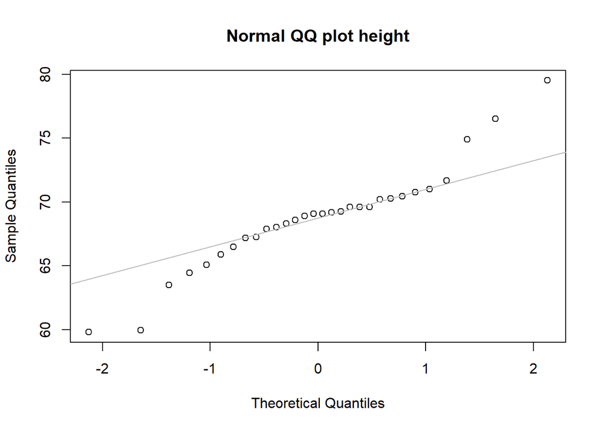

```r
qqnorm(height,main="Normal QQ plot height")
qqline(height,col="gray")
```

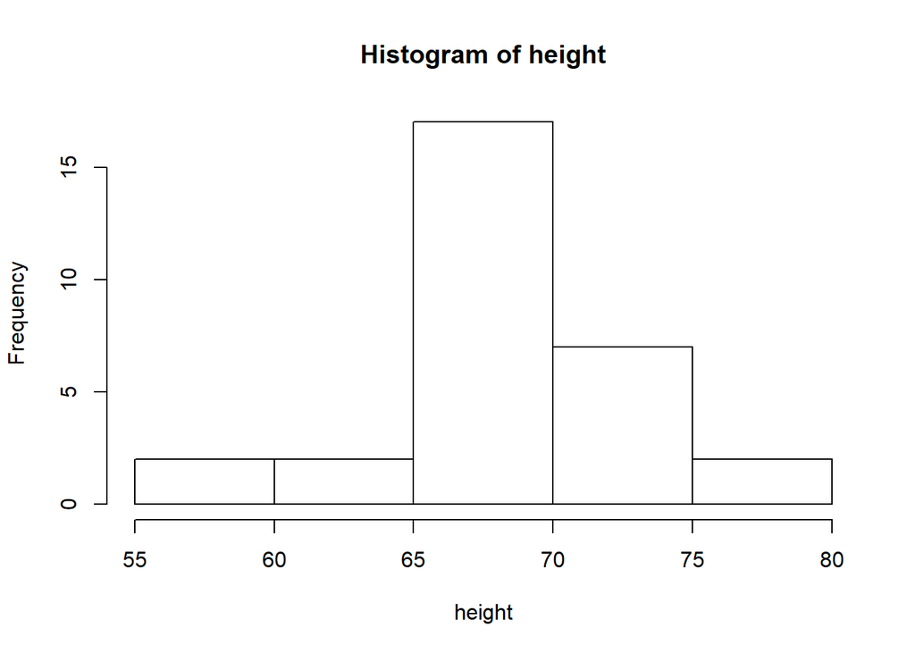

```r
hist(height)
```

```r
##Weight
mean(sample30$weight)
```

```
## [1] 147.8683
```

```r
sd(sample30$weight)
```

```
## [1] 18.27585
```

```r
se(weight)
```

```
## [1] 3.336698
```

```r
t.test(sample30$weight)
```

```
##
##  One Sample t-test
##
## data:  sample30$weight
## t = 44.316, df = 29, p-value < 2.2e-16
## alternative hypothesis: true mean is not equal to 0
## 95 percent confidence interval:
##  141.0440 154.6926
## sample estimates:
## mean of x
##  147.8683
```

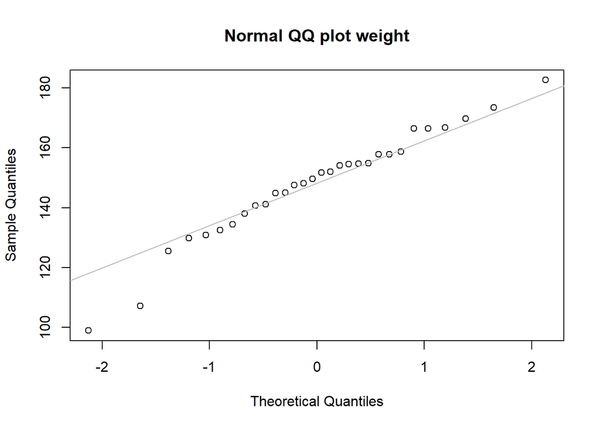

```r
qqnorm(weight,main="Normal QQ plot weight")
qqline(weight,col="gray")
```

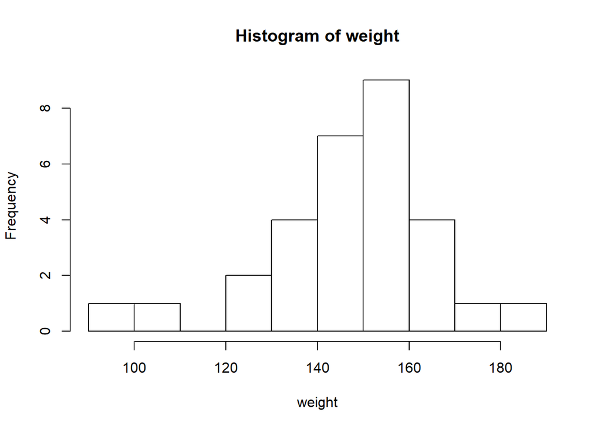

```r
hist(weight)
```

```r
##Age
mean(sample30$age)
```

```
## [1] 19.64386
```

```r
sd(sample30$age)
```

```
## [1] 2.823547
```

```r
se(age)
```

```
## [1] 0.5155067
```

```r
t.test(sample30$age)
```

```
##
##  One Sample t-test
##
## data:  sample30$age
## t = 38.106, df = 29, p-value < 2.2e-16
## alternative hypothesis: true mean is not equal to 0
## 95 percent confidence interval:
##  18.58953 20.69819
## sample estimates:
## mean of x
##  19.64386
```

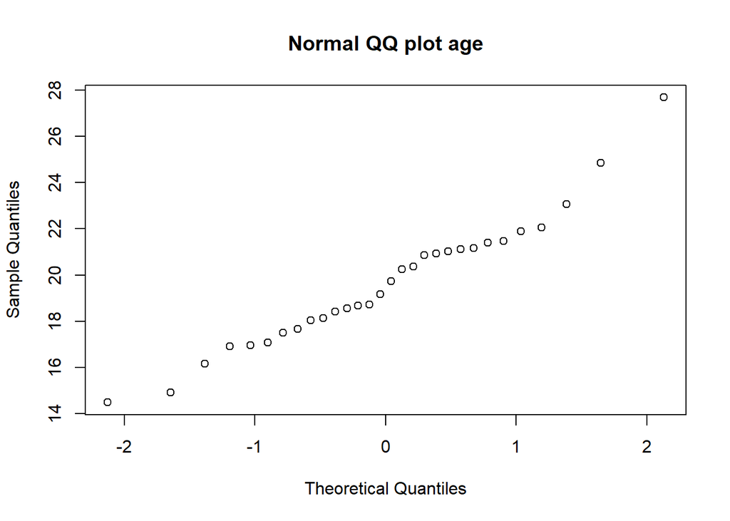

```r
qqnorm(age,main="Normal QQ plot age")
qqline(weight,col="gray")
```

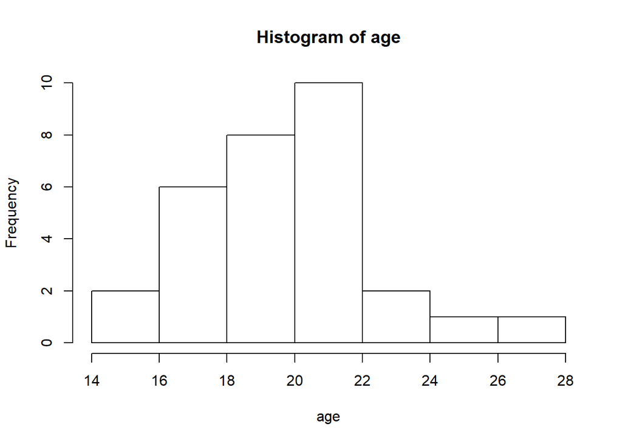

```r
hist(age)
```

```r
##Zombies killed

mean(sample30$zombies_killed)
```

```
## [1] 2.6
```

```r
sd(sample30$zombies_killed)
```

```
## [1] 1.693802
```

```r
se(sample30$zombies_killed)
```

```
## [1] 0.3092445
```

```r
t.test(sample30$zombies_killed)### CI are not done, I need to use another function or code because this is for normal and this variable is right skewed
```

```
##
##  One Sample t-test
##
## data:  sample30$zombies_killed
## t = 8.4076, df = 29, p-value = 2.888e-09
## alternative hypothesis: true mean is not equal to 0
## 95 percent confidence interval:
##  1.967524 3.232476
## sample estimates:
## mean of x
##       2.6
```

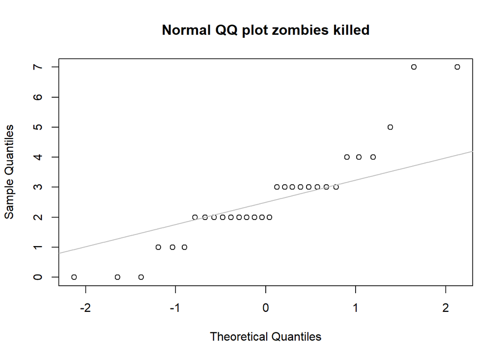

```r
qqnorm(zombies_killed,main="Normal QQ plot zombies killed")
qqline(zombies_killed,col="gray")
```

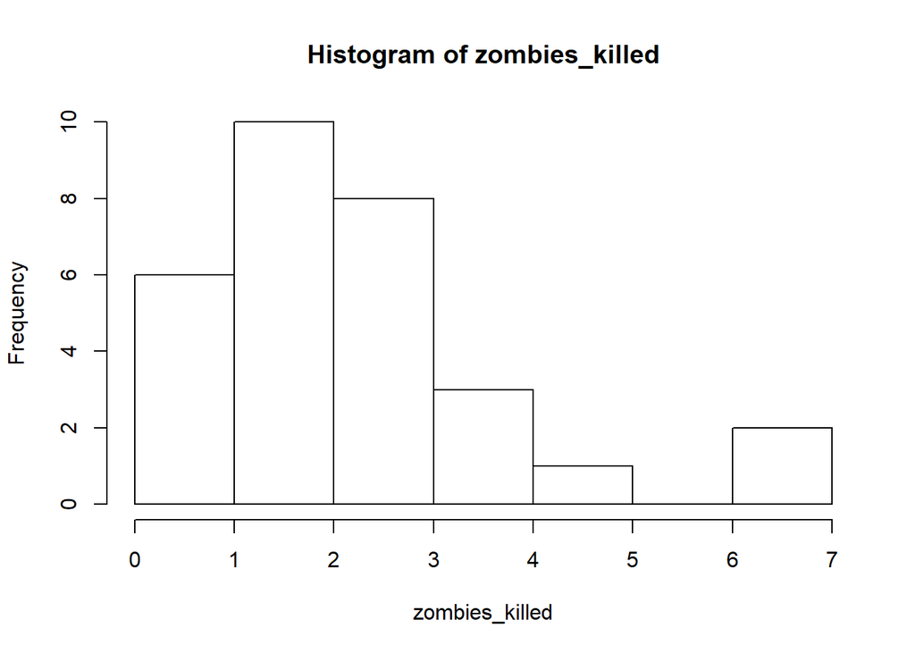

```r
hist(zombies_killed)
```

```r
##Years of education

mean(sample30$years_of_education)
```

```
## [1] 3.033333
```

```r
sd(sample30$years_of_education)
```

```
## [1] 1.629117
```

```r
se(sample30$years_of_education)
```

```
## [1] 0.2974348
```

```r
t.test(sample30$years_of_education)### CI are not done, I need to use another function or code because this is for normal and this variable is right skewed
```

```
##
##  One Sample t-test
##
## data:  sample30$years_of_education
## t = 10.198, df = 29, p-value = 4.219e-11
## alternative hypothesis: true mean is not equal to 0
## 95 percent confidence interval:
##  2.425011 3.641656
## sample estimates:
## mean of x
##  3.033333
```

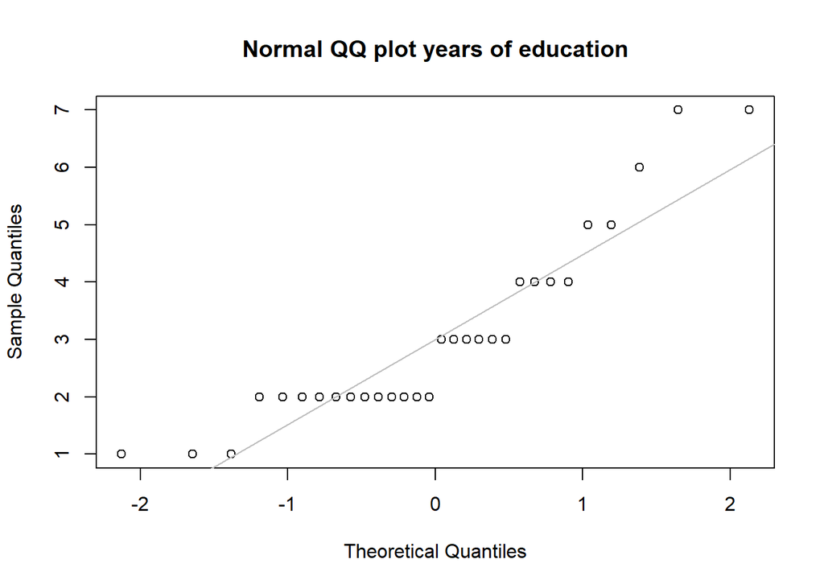

```r
qqnorm(years_of_education,main="Normal QQ plot years of education")
qqline(years_of_education,col="gray")
```

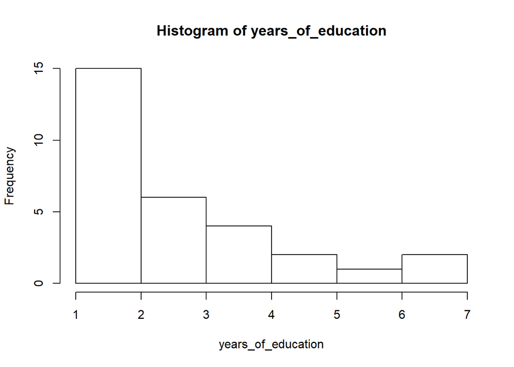

```r
hist(years_of_education)
```

```r
detach(sample30)
```

##6. Now draw 99 more random samples of 30 zombie apocalypse survivors, and calculate the mean for each variable for each of these samples. Together with the first sample you drew, you now have a set of 100 means for each variable (each based on 30 observations), which constitutes a sampling distribution for each variable. What are the means and standard deviations of this distribution of means for each variable? How do the standard deviations of means compare to the standard errors estimated in [5]? What do these sampling distributions look like (a graph might help here)? Are they normally distributed? What about for those variables that you concluded were not originally drawn from a normal distribution?

```r
attach(d)

k <- 99 # number of samples
n <- 30 # size of each sample
s <- NULL # dummy variable to hold each sample
for (i in 1:k){
    s[[i]] <- d[sample(1:nrow(d), 30,
   replace=FALSE),]
}
head(s)
```

[output not shown]

[output cut: 368 more lines]

```r
## I could do the 99 random samples but I do not know how to extract the mean of each variable

##this code does not work
##hm <- NULL
##for (i in 1:k){
##    hm[i] <- mean(s[[i]])
##    }
##mean(hm)
```